# Project: Investigate a Dataset (noshowappointments- data set!)

- Introduction
- Data Wrangling
- Exploratory Data Analysis
- Conclusions

## Introduction

> This dataset collects information from 100k medical appointments in Brazil and is focused on the question of whether or not patients show up for their appointment. A number of characteristics about the patient are included in each row. ScheduledDay, tells us on what day the patient set up their appointment. ‘Neighborhood’ indicates the location of the hospital. ‘Scholarship’ indicates whether or not the patient is enrolled in Brasilian welfare program Bolsa Família. the data set is provided by kaggel. throughout this project we are trying to answer these questions by exploring the dataset and also the connections among variables.

## Questions:

> (1)Are patient who missed an appointmant befor more likly to miss the next appointment? (2)What is the no-show proportion? (3)Are no-show appointments associated with a certain gender? (4)How are weekdays affecting patients absence? (5)How is age affecting patients absence?

## Data Wrangling

### General Properties

```python
#import libraries
import pandas as pd
import matplotlib.pyplot as plt
import numpy as np
%matplotlib inline
df=pd.read_csv('noshowappointments.csv')#open data st
df.head(10)#exploring the data
```

|  | PatientId | AppointmentID | Gender | ScheduledDay | AppointmentDay | Age | Neighbourhood | Scholarship | Hipertension | Diabetes | Alcoholism | Handcap | SMS_received | No-show |
| --- | --- | --- | --- | --- | --- | --- | --- | --- | --- | --- | --- | --- | --- | --- |
| 0 | 2.987250e+13 | 5642903 | F | 2016-04-29T18:38:08Z | 2016-04-29T00:00:00Z | 62 | JARDIM DA PENHA | 0 | 1 | 0 | 0 | 0 | 0 | No |
| 1 | 5.589980e+14 | 5642503 | M | 2016-04-29T16:08:27Z | 2016-04-29T00:00:00Z | 56 | JARDIM DA PENHA | 0 | 0 | 0 | 0 | 0 | 0 | No |
| 2 | 4.262960e+12 | 5642549 | F | 2016-04-29T16:19:04Z | 2016-04-29T00:00:00Z | 62 | MATA DA PRAIA | 0 | 0 | 0 | 0 | 0 | 0 | No |
| 3 | 8.679510e+11 | 5642828 | F | 2016-04-29T17:29:31Z | 2016-04-29T00:00:00Z | 8 | PONTAL DE CAMBURI | 0 | 0 | 0 | 0 | 0 | 0 | No |
| 4 | 8.841190e+12 | 5642494 | F | 2016-04-29T16:07:23Z | 2016-04-29T00:00:00Z | 56 | JARDIM DA PENHA | 0 | 1 | 1 | 0 | 0 | 0 | No |
| 5 | 9.598510e+13 | 5626772 | F | 2016-04-27T08:36:51Z | 2016-04-29T00:00:00Z | 76 | REPÚBLICA | 0 | 1 | 0 | 0 | 0 | 0 | No |
| 6 | 7.336880e+14 | 5630279 | F | 2016-04-27T15:05:12Z | 2016-04-29T00:00:00Z | 23 | GOIABEIRAS | 0 | 0 | 0 | 0 | 0 | 0 | Yes |
| 7 | 3.449830e+12 | 5630575 | F | 2016-04-27T15:39:58Z | 2016-04-29T00:00:00Z | 39 | GOIABEIRAS | 0 | 0 | 0 | 0 | 0 | 0 | Yes |
| 8 | 5.639470e+13 | 5638447 | F | 2016-04-29T08:02:16Z | 2016-04-29T00:00:00Z | 21 | ANDORINHAS | 0 | 0 | 0 | 0 | 0 | 0 | No |
| 9 | 7.812460e+13 | 5629123 | F | 2016-04-27T12:48:25Z | 2016-04-29T00:00:00Z | 19 | CONQUISTA | 0 | 0 | 0 | 0 | 0 | 0 | No |

> In order to understand the dataset we will call shape, info and describe.

```python
df.shape
```

```
(110527, 14)
```

> So, we have 110527 appoinmements were booked and 14 columns.

```python
df.info()
```

```
<class 'pandas.core.frame.DataFrame'>
RangeIndex: 110527 entries, 0 to 110526
Data columns (total 14 columns):
PatientId         110527 non-null float64
AppointmentID     110527 non-null int64
Gender            110527 non-null object
ScheduledDay      110527 non-null object
AppointmentDay    110527 non-null object
Age               110527 non-null int64
Neighbourhood     110527 non-null object
Scholarship       110527 non-null int64
Hipertension      110527 non-null int64
Diabetes          110527 non-null int64
Alcoholism        110527 non-null int64
Handcap           110527 non-null int64
SMS_received      110527 non-null int64
No-show           110527 non-null object
dtypes: float64(1), int64(8), object(5)
memory usage: 11.8+ MB
```

```python
df.describe()
```

|  | PatientId | AppointmentID | Age | Scholarship | Hipertension | Diabetes | Alcoholism | Handcap | SMS_received |
| --- | --- | --- | --- | --- | --- | --- | --- | --- | --- |
| count | 1.105270e+05 | 1.105270e+05 | 110527.000000 | 110527.000000 | 110527.000000 | 110527.000000 | 110527.000000 | 110527.000000 | 110527.000000 |
| mean | 1.474963e+14 | 5.675305e+06 | 37.088874 | 0.098266 | 0.197246 | 0.071865 | 0.030400 | 0.022248 | 0.321026 |
| std | 2.560949e+14 | 7.129575e+04 | 23.110205 | 0.297675 | 0.397921 | 0.258265 | 0.171686 | 0.161543 | 0.466873 |
| min | 3.920000e+04 | 5.030230e+06 | -1.000000 | 0.000000 | 0.000000 | 0.000000 | 0.000000 | 0.000000 | 0.000000 |
| 25% | 4.172615e+12 | 5.640286e+06 | 18.000000 | 0.000000 | 0.000000 | 0.000000 | 0.000000 | 0.000000 | 0.000000 |
| 50% | 3.173180e+13 | 5.680573e+06 | 37.000000 | 0.000000 | 0.000000 | 0.000000 | 0.000000 | 0.000000 | 0.000000 |
| 75% | 9.439170e+13 | 5.725524e+06 | 55.000000 | 0.000000 | 0.000000 | 0.000000 | 0.000000 | 0.000000 | 1.000000 |
| max | 9.999820e+14 | 5.790484e+06 | 115.000000 | 1.000000 | 1.000000 | 1.000000 | 1.000000 | 4.000000 | 1.000000 |

> We could see that the min age is -1 which is impossible! and no null values in all 14 coulmns, How lucky we are :) all columns type are okay but for AppointmentDay and ScheduledDay columns we will change it to datetime.

```python
df.duplicated().sum()
```

```
0
```

> No duplicated rows in the data set.

```python
df.isnull().sum()
```

```
PatientId         0
AppointmentID     0
Gender            0
ScheduledDay      0
AppointmentDay    0
Age               0
Neighbourhood     0
Scholarship       0
Hipertension      0
Diabetes          0
Alcoholism        0
Handcap           0
SMS_received      0
No-show           0
dtype: int64
```

> No null values in the data set.

### Data Cleaning

```python
#changing data type and column name
df.rename(columns={'No-show':'NoShow'},inplace=True)
# declaring a function
def changeToTime (c):
    df[c]=pd.to_datetime(df[c])

# calling the function
changeToTime('AppointmentDay')
changeToTime('ScheduledDay')


df['hour_scheduled']=df['ScheduledDay'].dt.hour

df['day_scheduled']=df['ScheduledDay'].dt.weekday_name
df['day_appointment']=df['AppointmentDay'].dt.weekday_name

df.info()
```

```
<class 'pandas.core.frame.DataFrame'>
RangeIndex: 110527 entries, 0 to 110526
Data columns (total 17 columns):
PatientId          110527 non-null float64
AppointmentID      110527 non-null int64
Gender             110527 non-null object
ScheduledDay       110527 non-null datetime64[ns]
AppointmentDay     110527 non-null datetime64[ns]
Age                110527 non-null int64
Neighbourhood      110527 non-null object
Scholarship        110527 non-null int64
Hipertension       110527 non-null int64
Diabetes           110527 non-null int64
Alcoholism         110527 non-null int64
Handcap            110527 non-null int64
SMS_received       110527 non-null int64
NoShow             110527 non-null object
hour_scheduled     110527 non-null int64
day_scheduled      110527 non-null object
day_appointment    110527 non-null object
dtypes: datetime64[ns](2), float64(1), int64(9), object(5)
memory usage: 14.3+ MB
```

> We have created a function ( changeToTime) to change AppointmentDay datatype and ScheduledDay to datetime64[ns].And change the No-show column to NoShow cause I have got a problem each time I deal with. Also I add new colunms hour_scheduled,day_scheduled, day_appointment where they determine the hour of scheduled, week day name of ScheduledDay and week day name of AppointmentDay ,respectively.

```python
df.query('Age == -1')
```

|  | PatientId | AppointmentID | Gender | ScheduledDay | AppointmentDay | Age | Neighbourhood | Scholarship | Hipertension | Diabetes | Alcoholism | Handcap | SMS_received | NoShow | hour_scheduled | day_scheduled | day_appointment |
| --- | --- | --- | --- | --- | --- | --- | --- | --- | --- | --- | --- | --- | --- | --- | --- | --- | --- |
| 99832 | 4.659430e+14 | 5775010 | F | 2016-06-06 08:58:13 | 2016-06-06 | -1 | ROMÃO | 0 | 0 | 0 | 0 | 0 | 0 | No | 8 | Monday | Monday |

```python
df.drop(99832,axis=0,inplace=True)
df.describe()
```

|  | PatientId | AppointmentID | Age | Scholarship | Hipertension | Diabetes | Alcoholism | Handcap | SMS_received | hour_scheduled |
| --- | --- | --- | --- | --- | --- | --- | --- | --- | --- | --- |
| count | 1.105260e+05 | 1.105260e+05 | 110526.000000 | 110526.000000 | 110526.000000 | 110526.000000 | 110526.000000 | 110526.000000 | 110526.000000 | 110526.000000 |
| mean | 1.474934e+14 | 5.675304e+06 | 37.089219 | 0.098266 | 0.197248 | 0.071865 | 0.030400 | 0.022248 | 0.321029 | 10.774542 |
| std | 2.560943e+14 | 7.129544e+04 | 23.110026 | 0.297676 | 0.397923 | 0.258266 | 0.171686 | 0.161543 | 0.466874 | 3.216192 |
| min | 3.920000e+04 | 5.030230e+06 | 0.000000 | 0.000000 | 0.000000 | 0.000000 | 0.000000 | 0.000000 | 0.000000 | 6.000000 |
| 25% | 4.172538e+12 | 5.640285e+06 | 18.000000 | 0.000000 | 0.000000 | 0.000000 | 0.000000 | 0.000000 | 0.000000 | 8.000000 |
| 50% | 3.173180e+13 | 5.680572e+06 | 37.000000 | 0.000000 | 0.000000 | 0.000000 | 0.000000 | 0.000000 | 0.000000 | 10.000000 |
| 75% | 9.438960e+13 | 5.725523e+06 | 55.000000 | 0.000000 | 0.000000 | 0.000000 | 0.000000 | 0.000000 | 1.000000 | 13.000000 |
| max | 9.999820e+14 | 5.790484e+06 | 115.000000 | 1.000000 | 1.000000 | 1.000000 | 1.000000 | 4.000000 | 1.000000 | 21.000000 |

```python
df.shape
```

```
(110526, 17)
```

> We have deleted the row where -1 value in age.

```python
df.replace(('Yes', 'No'), (1, 0), inplace=True)
```

> To make the data more Understandable and easy to deal with, We have changed the No, yes values in the data set to 0,1.

```python
df['AppointmentsMissed'] =df.groupby('PatientId')['NoShow'].apply(lambda x: x.cumsum())

df.query('AppointmentsMissed > 1 ')
```

|  | PatientId | AppointmentID | Gender | ScheduledDay | AppointmentDay | Age | Neighbourhood | Scholarship | Hipertension | Diabetes | Alcoholism | Handcap | SMS_received | NoShow | hour_scheduled | day_scheduled | day_appointment | AppointmentsMissed |
| --- | --- | --- | --- | --- | --- | --- | --- | --- | --- | --- | --- | --- | --- | --- | --- | --- | --- | --- |
| 288 | 2.246210e+13 | 5532908 | M | 2016-03-31 12:39:06 | 2016-04-29 | 43 | CARATOÍRA | 0 | 0 | 0 | 0 | 0 | 1 | 1 | 12 | Thursday | Friday | 2 |
| 415 | 7.273890e+12 | 5601968 | F | 2016-04-19 14:02:07 | 2016-04-29 | 29 | ITARARÉ | 1 | 0 | 0 | 0 | 0 | 0 | 1 | 14 | Tuesday | Friday | 2 |
| 419 | 7.273890e+12 | 5639757 | F | 2016-04-29 09:32:22 | 2016-04-29 | 29 | ITARARÉ | 1 | 0 | 0 | 0 | 0 | 0 | 0 | 9 | Friday | Friday | 2 |
| 500 | 3.265240e+12 | 5483275 | F | 2016-03-17 11:09:11 | 2016-04-29 | 12 | ITARARÉ | 0 | 0 | 0 | 0 | 0 | 0 | 1 | 11 | Thursday | Friday | 2 |
| 554 | 4.916360e+12 | 5521769 | M | 2016-03-29 12:40:26 | 2016-04-29 | 40 | CENTRO | 0 | 0 | 0 | 0 | 0 | 0 | 1 | 12 | Tuesday | Friday | 2 |
| 1071 | 7.466640e+13 | 5595502 | F | 2016-04-18 12:57:33 | 2016-04-29 | 1 | SÃO JOSÉ | 0 | 0 | 0 | 0 | 0 | 0 | 1 | 12 | Monday | Friday | 2 |
| 1074 | 2.958720e+12 | 5595649 | F | 2016-04-18 13:17:29 | 2016-04-29 | 2 | SÃO JOSÉ | 0 | 0 | 0 | 0 | 0 | 1 | 1 | 13 | Monday | Friday | 2 |
| 1083 | 4.193440e+14 | 5595748 | M | 2016-04-18 13:25:51 | 2016-04-29 | 2 | SÃO JOSÉ | 0 | 0 | 0 | 0 | 0 | 0 | 1 | 13 | Monday | Friday | 2 |
| 1090 | 2.789140e+14 | 5595578 | F | 2016-04-18 13:10:16 | 2016-04-29 | 2 | SÃO JOSÉ | 0 | 0 | 0 | 0 | 0 | 0 | 1 | 13 | Monday | Friday | 2 |
| 1437 | 8.955630e+14 | 5595910 | M | 2016-04-18 13:38:47 | 2016-04-29 | 10 | DO QUADRO | 0 | 0 | 0 | 0 | 0 | 0 | 1 | 13 | Monday | Friday | 2 |
| 1451 | 9.921950e+13 | 5422579 | F | 2016-03-02 15:56:03 | 2016-04-29 | 34 | SANTA TEREZA | 1 | 0 | 0 | 0 | 0 | 1 | 1 | 15 | Wednesday | Friday | 2 |
| 1554 | 7.695330e+12 | 5642524 | F | 2016-04-29 16:12:47 | 2016-04-29 | 13 | DA PENHA | 0 | 0 | 0 | 0 | 0 | 0 | 1 | 16 | Friday | Friday | 2 |
| 1557 | 1.144470e+12 | 5590628 | F | 2016-04-15 14:35:51 | 2016-04-29 | 21 | BENTO FERREIRA | 0 | 0 | 0 | 0 | 0 | 0 | 1 | 14 | Friday | Friday | 2 |
| 1558 | 1.144470e+12 | 5590627 | F | 2016-04-15 14:35:51 | 2016-04-29 | 21 | BENTO FERREIRA | 0 | 0 | 0 | 0 | 0 | 0 | 1 | 14 | Friday | Friday | 3 |
| 1636 | 4.788220e+14 | 5618125 | F | 2016-04-26 06:24:33 | 2016-04-29 | 38 | ROMÃO | 1 | 1 | 0 | 0 | 0 | 1 | 1 | 6 | Tuesday | Friday | 2 |
| 1741 | 2.883290e+13 | 5555284 | M | 2016-04-07 09:50:19 | 2016-04-29 | 32 | RESISTÊNCIA | 0 | 0 | 0 | 0 | 0 | 1 | 1 | 9 | Thursday | Friday | 2 |
| 1773 | 4.916360e+12 | 5521774 | M | 2016-03-29 12:41:06 | 2016-04-29 | 40 | CENTRO | 0 | 0 | 0 | 0 | 0 | 0 | 1 | 12 | Tuesday | Friday | 3 |
| 1775 | 4.916360e+12 | 5521773 | M | 2016-03-29 12:41:06 | 2016-04-29 | 40 | CENTRO | 0 | 0 | 0 | 0 | 0 | 0 | 1 | 12 | Tuesday | Friday | 4 |
| 1885 | 6.872330e+14 | 5613149 | M | 2016-04-25 09:04:01 | 2016-04-29 | 12 | ROMÃO | 0 | 1 | 0 | 0 | 0 | 0 | 1 | 9 | Monday | Friday | 2 |
| 1892 | 5.334230e+14 | 5537871 | F | 2016-04-01 10:44:39 | 2016-04-29 | 30 | ROMÃO | 0 | 0 | 0 | 0 | 0 | 0 | 1 | 10 | Friday | Friday | 2 |
| 1940 | 8.499860e+14 | 5490132 | M | 2016-03-18 14:15:57 | 2016-04-29 | 44 | FORTE SÃO JOÃO | 0 | 1 | 0 | 1 | 0 | 1 | 1 | 14 | Friday | Friday | 2 |
| 1955 | 2.143350e+13 | 5606015 | F | 2016-04-20 09:43:52 | 2016-04-29 | 24 | NOVA PALESTINA | 0 | 0 | 0 | 0 | 0 | 1 | 1 | 9 | Wednesday | Friday | 2 |
| 2096 | 5.454180e+13 | 5624272 | F | 2016-04-26 15:36:21 | 2016-04-29 | 0 | REDENÇÃO | 0 | 0 | 0 | 0 | 0 | 0 | 1 | 15 | Tuesday | Friday | 2 |
| 2100 | 5.654828e+10 | 5599183 | F | 2016-04-19 08:34:46 | 2016-04-29 | 40 | SANTO ANDRÉ | 0 | 0 | 0 | 0 | 0 | 1 | 1 | 8 | Tuesday | Friday | 2 |
| 2101 | 9.491860e+12 | 5600511 | F | 2016-04-19 10:46:27 | 2016-04-29 | 33 | REDENÇÃO | 0 | 0 | 0 | 0 | 1 | 0 | 1 | 10 | Tuesday | Friday | 2 |
| 2110 | 2.599260e+11 | 5607092 | F | 2016-04-20 11:04:38 | 2016-04-29 | 6 | DO QUADRO | 1 | 0 | 0 | 0 | 0 | 1 | 1 | 11 | Wednesday | Friday | 2 |
| 2188 | 3.896263e+10 | 5578518 | F | 2016-04-13 12:41:35 | 2016-04-29 | 8 | CARATOÍRA | 0 | 0 | 0 | 0 | 0 | 0 | 1 | 12 | Wednesday | Friday | 2 |
| 2250 | 2.317810e+13 | 5614567 | F | 2016-04-25 10:43:52 | 2016-04-29 | 30 | GURIGICA | 0 | 0 | 0 | 0 | 0 | 0 | 1 | 10 | Monday | Friday | 2 |
| 2337 | 1.529570e+11 | 5558627 | M | 2016-04-07 17:39:24 | 2016-04-29 | 39 | MARUÍPE | 0 | 0 | 0 | 0 | 0 | 0 | 1 | 17 | Thursday | Friday | 2 |
| 2365 | 4.266840e+11 | 5617266 | F | 2016-04-25 15:46:38 | 2016-04-29 | 0 | FORTE SÃO JOÃO | 0 | 0 | 0 | 0 | 0 | 0 | 1 | 15 | Monday | Friday | 2 |
| ... | ... | ... | ... | ... | ... | ... | ... | ... | ... | ... | ... | ... | ... | ... | ... | ... | ... | ... |
| 110232 | 1.121150e+14 | 5676082 | F | 2016-05-09 14:56:13 | 2016-06-08 | 1 | RESISTÊNCIA | 0 | 0 | 0 | 0 | 0 | 1 | 1 | 14 | Monday | Wednesday | 2 |
| 110240 | 1.813560e+13 | 5752292 | F | 2016-05-31 11:29:29 | 2016-06-01 | 29 | MARIA ORTIZ | 0 | 0 | 0 | 0 | 0 | 0 | 1 | 11 | Tuesday | Wednesday | 2 |
| 110241 | 3.917390e+13 | 5704373 | F | 2016-05-16 15:35:53 | 2016-06-01 | 21 | MARIA ORTIZ | 0 | 0 | 0 | 0 | 0 | 1 | 1 | 15 | Monday | Wednesday | 3 |
| 110249 | 1.537910e+13 | 5656416 | M | 2016-05-04 08:01:21 | 2016-06-06 | 41 | MARIA ORTIZ | 0 | 0 | 0 | 0 | 0 | 0 | 1 | 8 | Wednesday | Monday | 2 |
| 110278 | 3.636213e+10 | 5624608 | M | 2016-04-26 16:28:01 | 2016-06-01 | 62 | MARIA ORTIZ | 0 | 0 | 0 | 0 | 0 | 1 | 0 | 16 | Tuesday | Wednesday | 2 |
| 110289 | 2.636520e+14 | 5759557 | M | 2016-06-01 13:16:17 | 2016-06-02 | 16 | CONQUISTA | 1 | 0 | 0 | 0 | 0 | 0 | 0 | 13 | Wednesday | Thursday | 2 |
| 110292 | 4.462250e+12 | 5756544 | M | 2016-06-01 08:25:36 | 2016-06-02 | 10 | RESISTÊNCIA | 0 | 0 | 0 | 0 | 0 | 0 | 1 | 8 | Wednesday | Thursday | 4 |
| 110300 | 4.994690e+13 | 5753782 | M | 2016-05-31 14:47:38 | 2016-06-07 | 22 | RESISTÊNCIA | 0 | 0 | 0 | 0 | 0 | 1 | 1 | 14 | Tuesday | Tuesday | 2 |
| 110318 | 1.316870e+12 | 5621214 | F | 2016-04-26 09:59:33 | 2016-06-06 | 3 | RESISTÊNCIA | 0 | 0 | 0 | 0 | 0 | 0 | 1 | 9 | Tuesday | Monday | 2 |
| 110332 | 7.921130e+11 | 5603681 | F | 2016-04-20 07:17:43 | 2016-06-08 | 4 | RESISTÊNCIA | 0 | 0 | 0 | 0 | 0 | 1 | 1 | 7 | Wednesday | Wednesday | 3 |
| 110333 | 3.411450e+14 | 5787006 | M | 2016-06-08 09:13:22 | 2016-06-08 | 1 | RESISTÊNCIA | 0 | 0 | 0 | 0 | 0 | 0 | 0 | 9 | Wednesday | Wednesday | 2 |
| 110361 | 9.323780e+12 | 5762326 | F | 2016-06-02 07:35:03 | 2016-06-02 | 33 | RESISTÊNCIA | 0 | 0 | 0 | 0 | 0 | 0 | 0 | 7 | Thursday | Thursday | 2 |
| 110371 | 2.558640e+14 | 5655443 | M | 2016-05-03 17:14:58 | 2016-06-01 | 38 | RESISTÊNCIA | 0 | 0 | 0 | 0 | 0 | 1 | 1 | 17 | Tuesday | Wednesday | 2 |
| 110373 | 3.334790e+11 | 5655438 | M | 2016-05-03 17:14:35 | 2016-06-01 | 8 | RESISTÊNCIA | 0 | 0 | 0 | 0 | 0 | 1 | 1 | 17 | Tuesday | Wednesday | 2 |
| 110379 | 7.645610e+11 | 5583030 | F | 2016-04-14 10:19:46 | 2016-06-01 | 16 | RESISTÊNCIA | 0 | 0 | 0 | 0 | 0 | 1 | 1 | 10 | Thursday | Wednesday | 3 |
| 110386 | 2.957280e+12 | 5582576 | F | 2016-04-14 09:37:34 | 2016-06-01 | 48 | RESISTÊNCIA | 0 | 1 | 0 | 0 | 0 | 1 | 1 | 9 | Thursday | Wednesday | 2 |
| 110389 | 6.249430e+13 | 5709051 | M | 2016-05-17 12:51:03 | 2016-06-07 | 29 | RESISTÊNCIA | 0 | 0 | 0 | 0 | 0 | 1 | 0 | 12 | Tuesday | Tuesday | 2 |
| 110399 | 9.437120e+13 | 5692938 | F | 2016-05-12 16:47:53 | 2016-06-07 | 17 | RESISTÊNCIA | 0 | 1 | 0 | 0 | 0 | 1 | 1 | 16 | Thursday | Tuesday | 3 |
| 110400 | 8.382850e+11 | 5739407 | F | 2016-05-25 13:29:23 | 2016-06-07 | 36 | RESISTÊNCIA | 1 | 0 | 0 | 0 | 0 | 1 | 1 | 13 | Wednesday | Tuesday | 3 |
| 110412 | 3.334790e+11 | 5759227 | M | 2016-06-01 12:03:47 | 2016-06-06 | 8 | RESISTÊNCIA | 0 | 0 | 0 | 0 | 0 | 1 | 0 | 12 | Wednesday | Monday | 2 |
| 110415 | 6.717880e+13 | 5658645 | M | 2016-05-04 11:29:17 | 2016-06-06 | 59 | RESISTÊNCIA | 0 | 0 | 0 | 0 | 0 | 0 | 1 | 11 | Wednesday | Monday | 2 |
| 110424 | 3.334790e+11 | 5695147 | M | 2016-05-13 09:37:16 | 2016-06-08 | 8 | RESISTÊNCIA | 0 | 0 | 0 | 0 | 0 | 1 | 0 | 9 | Friday | Wednesday | 2 |
| 110425 | 2.558640e+14 | 5695130 | M | 2016-05-13 09:35:56 | 2016-06-08 | 38 | RESISTÊNCIA | 0 | 0 | 0 | 0 | 0 | 1 | 0 | 9 | Friday | Wednesday | 2 |
| 110430 | 4.986160e+13 | 5736999 | F | 2016-05-25 09:01:33 | 2016-06-01 | 57 | RESISTÊNCIA | 0 | 0 | 0 | 0 | 0 | 0 | 1 | 9 | Wednesday | Wednesday | 3 |
| 110431 | 2.175330e+12 | 5769362 | M | 2016-06-03 08:45:25 | 2016-06-08 | 12 | RESISTÊNCIA | 0 | 0 | 0 | 0 | 0 | 1 | 1 | 8 | Friday | Wednesday | 2 |
| 110452 | 6.338840e+14 | 5701786 | F | 2016-05-16 11:00:12 | 2016-06-06 | 39 | RESISTÊNCIA | 0 | 1 | 0 | 0 | 0 | 1 | 0 | 11 | Monday | Monday | 3 |
| 110454 | 6.142460e+11 | 5772400 | F | 2016-06-03 15:18:44 | 2016-06-03 | 0 | RESISTÊNCIA | 0 | 0 | 0 | 0 | 0 | 0 | 0 | 15 | Friday | Friday | 2 |
| 110484 | 5.133650e+14 | 5772155 | F | 2016-06-03 14:43:56 | 2016-06-07 | 45 | BARRO VERMELHO | 0 | 0 | 0 | 0 | 0 | 0 | 1 | 14 | Friday | Tuesday | 2 |
| 110496 | 8.544300e+13 | 5779046 | F | 2016-06-06 17:35:38 | 2016-06-08 | 37 | MARIA ORTIZ | 0 | 1 | 0 | 0 | 0 | 0 | 1 | 17 | Monday | Wednesday | 3 |
| 110515 | 6.456340e+14 | 5778621 | M | 2016-06-06 15:58:05 | 2016-06-08 | 33 | MARIA ORTIZ | 0 | 1 | 0 | 0 | 0 | 0 | 1 | 15 | Monday | Wednesday | 2 |

7492 rows × 18 columns

> We have added a new column AppointmentsMissed which sums how many has the patient been absent. I would like to see if there is a relation between NoShow and AppointmentsMissed.

## Exploratory Data Analysis

### Research Question 1 (Are patient who missed an appointmant befor more likly to miss the next appointment?)

```python
df.corr()
```

|  | PatientId | AppointmentID | Age | Scholarship | Hipertension | Diabetes | Alcoholism | Handcap | SMS_received | NoShow | hour_scheduled | AppointmentsMissed |
| --- | --- | --- | --- | --- | --- | --- | --- | --- | --- | --- | --- | --- |
| PatientId | 1.000000 | 0.004023 | -0.004121 | -0.002877 | -0.006436 | 0.001608 | 0.011014 | -0.007915 | -0.009742 | -0.001456 | 0.001937 | -0.005307 |
| AppointmentID | 0.004023 | 1.000000 | -0.019106 | 0.022619 | 0.012759 | 0.022632 | 0.032946 | 0.014107 | -0.256613 | -0.162597 | -0.049345 | -0.011363 |
| Age | -0.004121 | -0.019106 | 1.000000 | -0.092463 | 0.504586 | 0.292391 | 0.095810 | 0.078032 | 0.012633 | -0.060327 | 0.014139 | -0.044330 |
| Scholarship | -0.002877 | 0.022619 | -0.092463 | 1.000000 | -0.019730 | -0.024894 | 0.035022 | -0.008587 | 0.001192 | 0.029134 | -0.024394 | 0.047663 |
| Hipertension | -0.006436 | 0.012759 | 0.504586 | -0.019730 | 1.000000 | 0.433085 | 0.087970 | 0.080083 | -0.006270 | -0.035704 | -0.033226 | -0.024065 |
| Diabetes | 0.001608 | 0.022632 | 0.292391 | -0.024894 | 0.433085 | 1.000000 | 0.018473 | 0.057530 | -0.014552 | -0.015181 | -0.014413 | -0.010360 |
| Alcoholism | 0.011014 | 0.032946 | 0.095810 | 0.035022 | 0.087970 | 0.018473 | 1.000000 | 0.004647 | -0.026149 | -0.000197 | -0.002711 | 0.006366 |
| Handcap | -0.007915 | 0.014107 | 0.078032 | -0.008587 | 0.080083 | 0.057530 | 0.004647 | 1.000000 | -0.024162 | -0.006077 | 0.002671 | 0.019510 |
| SMS_received | -0.009742 | -0.256613 | 0.012633 | 0.001192 | -0.006270 | -0.014552 | -0.026149 | -0.024162 | 1.000000 | 0.126428 | 0.060308 | 0.048684 |
| NoShow | -0.001456 | -0.162597 | -0.060327 | 0.029134 | -0.035704 | -0.015181 | -0.000197 | -0.006077 | 0.126428 | 1.000000 | 0.060693 | 0.580121 |
| hour_scheduled | 0.001937 | -0.049345 | 0.014139 | -0.024394 | -0.033226 | -0.014413 | -0.002711 | 0.002671 | 0.060308 | 0.060693 | 1.000000 | 0.066618 |
| AppointmentsMissed | -0.005307 | -0.011363 | -0.044330 | 0.047663 | -0.024065 | -0.010360 | 0.006366 | 0.019510 | 0.048684 | 0.580121 | 0.066618 | 1.000000 |

> Since the correlation is 0.58 , that means there is a possitive relationship between NoShow and AppointmentsMissed

### Research Question 2 (What is the no-show proportion?)

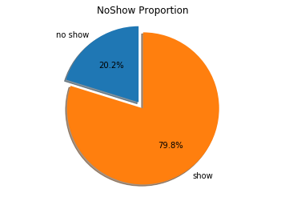

```python
# yes means patient no show, No means patient show.
df['NoShow'].value_counts()
df_yes=df.query('NoShow == 1')
df_no=df.query('NoShow == 0')
ff1=(df_yes.shape[0]/df.shape[0])*100 # no show percentage
ff2=(df_no.shape[0]/df.shape[0])*100 # no show percentage


labels = ['no show', 'show']
sizes = [ff1, ff2]
explode = (0.1,0) # only "explode" the 1st slice

fig1, ax1 = plt.subplots()
ax1.pie(sizes, explode=explode, labels=labels, autopct='%1.1f%%',
        shadow=True, startangle=90)
ax1.axis('equal')
plt.title('NoShow Proportion')
plt.show()
```

> 20.2% of appointments were missed.

### Research Question 3 (Are no-show appointments associated with a certain gender?)

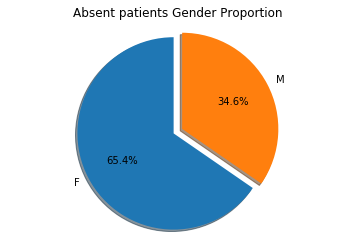

```python
female_prop=df_yes.query('Gender =="F"')
male_prop=df_yes.query('Gender =="M"')
g1=female_prop.shape[0]/df_yes.shape[0]
g2=male_prop.shape[0]/df_yes.shape[0]
labels = 'F','M'
sizes = [g1,g2]
explode = (0.1,0) # only "explode" the 1st slice

fig1, ax1 = plt.subplots()
ax1.pie(sizes, explode=explode, labels=labels, autopct='%1.1f%%',
        shadow=True, startangle=90)
ax1.axis('equal')
plt.title('Absent patients Gender Proportion')
plt.show()
```

> As shown in the plot , Female are more expected to not show with proportion 65.4% That is maybe because of their busy life.

### Research Question 4 ( How are weekdays affecting patients absence?)

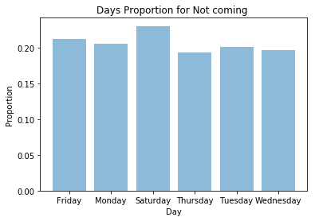

```python
m=df_yes.day_appointment.value_counts()/df.day_appointment.value_counts()
#plt.bar(m.index,m)


y_pos = np.arange(len(m.index))


plt.bar(y_pos, m, align='center', alpha=0.5)
plt.xticks(y_pos, m.index)
plt.xlabel('Day')
plt.ylabel('Proportion')
plt.title('Days Proportion for Not coming ')

plt.show()
```

> As shown in the plot, Saturday is more likely to has not coming patients. And I think that because Saturday is weekend where people used to have a plan, or to relax at home.

### Research Question 5 ( How is age affecting patients absence?)

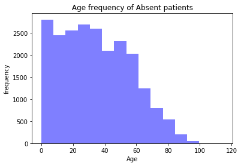

```python
x = df_yes['Age']
num_bins = 15
n, bins, patches = plt.hist(x, num_bins, facecolor='blue', alpha=0.5)
plt.xlabel('Age')
plt.ylabel('frequency')
plt.title(' Age frequency of Absent patients ')
plt.show()
```

> Clearly , the more Age is increasing the less likly that patient will be absent.

## Conclusions

> noshowappointments data set is very interesting, it has alot of columns that all contribute to affect the NoShow situation.I did alot of wrangling such as ( adding columns, deleting rows, rename columns, changing datatype of columns). I tried to see How ( Gender, Age,weekday, AppointmentsMissed) will affect the patient absence.Then I plot a visuals to show results. to conclude, There are alot of factors affect NoShow situation, some of them are age, gender, week day, how many AppointmentsMissed. although there are more factors also affect NoShow we have not discussed here.